# Champion Facilities and Reporting Bias

## Overview

Aggregated DHIS2 totals are a joint function of two things: the number of cases that occurred, and the number of facilities that reported. When reporting participation changes over time — and it always does — the aggregate total changes even if the underlying incidence is stable. This is **reporting bias**.

This vignette:

1. Demonstrates reporting bias in Lao PDR malaria surveillance data.
2. Reproduces the two diagnostic charts at the top of MG2’s Reporting tab to show how champions are identified and why the date range of analysis matters.
3. Compares the champion-facility trend against the raw trend to show how bias is removed.
4. Shows how element selection and the strictness of the reporting criterion affect the champion set.

*Prerequisite:* The mechanics of COUNT vs. SUM in the MG2 API download, and why COUNT = 1 at the leaf-facility level, are covered in the companion vignette *Facility Counts and Data Element Reporting in DHIS2*. Read that first for the counting concepts that underpin champion identification.

## 1 Background: reporting bias in DHIS2

### 1.1 Why the facility count is not constant

In a national HMIS, the number of facilities reporting a given data element changes over time: new facilities open, others close, reporting guidelines change, and individual facilities may periodically lack staff or connectivity. The problem arises when analysts treat aggregate totals as if the denominator were constant.

A submitted form that is partially blank still counts as “complete” in DHIS2 — 100% dataset reporting coexists with 0% data element reporting. This distinction is explained in detail in the companion vignette.

### 1.2 The WHO guidance gap

Even the WHO Data Quality Tool, which internally uses field-level completeness, conflates the two levels in its documentation, stating that dataset reporting rates “will also tell you for which years there are data for the data element.” This is only true if submitted forms are never blank — an assumption that fails routinely in practice.

## 2 Data and preparation

The examples use the MG2 bundled demo dataset: Lao PDR malaria surveillance data from the public DHIS2 demo server.

```r
library(MG2)
library(tsibble)
library(data.table)
library(dplyr)
```

```r
library(ggplot2)
library(patchwork)
library(scales)

demo  <- mg2_demo_dir()
d     <- read_file(file.path(demo, "malaria_demo.rds"))
d_c   <- cleanedData(d, source = "Original")
setDT(d_c)

cat("Rows:", format(nrow(d_c), big.mark = ","),
    "| Facilities:", uniqueN(d_c$orgUnit),
    "| Period:", format(min(d_c$Month)), "–", format(max(d_c$Month)), "\n")
```

```
#> Rows: 867,272 | Facilities: 1534 | Period: 2021 Aug – 2026 May
```

```r
# Date range per data element — essential context for choosing analysis periods
base_ranges <- d_c[!is.na(original),
  .(from  = format(min(Month)),
    to    = format(max(Month)),
    n_fac = uniqueN(orgUnit)),
  by = .(element = sub("_.*", "", data))
][order(from)]

knitr::kable(base_ranges,
  caption = paste0("Table 1. Date range and facility count for each data element",
                   " in the bundled demo dataset."),
  col.names = c("Data element", "First month", "Last month", "Facilities"))
```

Table 1. Date range and facility count for each data element in the bundled demo dataset.

| Data element | First month | Last month | Facilities |
| --- | --- | --- | --- |
| MAL - Total malaria cases (confirmed + presumed) | 2021 Aug | 2026 May | 992 |
| DQ - Malaria confirmed cases outlier threshold (mean + 3 SD) | 2022 Feb | 2026 May | 700 |
| MAL - Malaria suspects tested with microscopy | 2022 Jan | 2026 May | 543 |
| MAL - Plasmodium falciparum (RDT) | 2022 Jan | 2026 May | 738 |
| MAL - Malaria cases treated with 1st-line treatment courses (incl. ACTs) | 2022 Jan | 2026 May | 858 |
| MAL - Suspected malaria cases | 2022 Jan | 2026 May | 1292 |
| MAL - Microscopy positive malaria cases | 2022 Jan | 2026 May | 381 |
| MAL - Malaria suspects tested (RDT) | 2022 Jan | 2026 May | 1290 |
| MAL - RDT positive malaria cases | 2022 Jan | 2026 May | 832 |
| GEN - All-cause inpatients | 2022 Jan | 2026 May | 1193 |
| MAL - All-cause death | 2022 Jan | 2026 May | 486 |
| GEN - All-cause outpatients | 2022 Jan | 2026 May | 1227 |
| MAL - Malaria deaths | 2022 Jul | 2026 May | 1482 |
| MAL - Suspected malaria cases (pregnant women) | 2023 Apr | 2026 May | 879 |
| MAL - Inpatient malaria cases | 2024 Jan | 2026 May | 204 |
| MAL - RDT stock out days | 2024 Mar | 2026 May | 1140 |
| MAL - Confirmed malaria cases | 2024 Nov | 2026 May | 605 |
| MAL - Presumed malaria cases | 2024 Nov | 2026 May | 605 |

Two observations from Table 1 are critical for all subsequent analyses:

- **MAL - RDT positive malaria cases** is available from January 2022, with a dramatic increase in reporting facilities in 2024 (see Section 3.2). This element is used for the main trend analyses.
- **MAL - Confirmed malaria cases** is available only from **November 2024**. It represents an aggregate field for confirmed cases that was either introduced or began being widely used in late 2024. This affects element selection (Section 5) and means it cannot anchor a long-term champion analysis.

```r
# Named element groups used throughout
rdt_pos_cats  <- grep("MAL - RDT positive malaria cases",
                      unique(d_c$data), value = TRUE)
tested_cats   <- grep("MAL - Malaria suspects tested \\(RDT\\)",
                      unique(d_c$data), value = TRUE)
conf_cats     <- grep("MAL - Confirmed malaria cases",
                      unique(d_c$data), value = TRUE)
micro_cats    <- grep("MAL - Microscopy positive malaria cases",
                      unique(d_c$data), value = TRUE)

# Facility lookup
fac_meta <- unique(d_c[, .(orgUnit, Province)])
n_total  <- uniqueN(d_c$orgUnit)
```

## 3 Reporting completeness over time

### 3.1 Monthly facility counts, 2022–2026

The analysis period is restricted to **January 2022 – May 2026**, the period for which RDT positive data are available. Analyses restricted to later windows are noted explicitly.

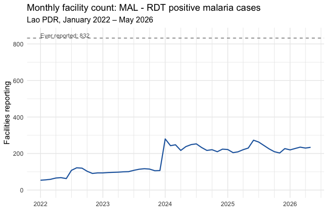

```r
# Restrict to RDT positive, 2022 onwards
monthly_n <- d_c[
  data %in% rdt_pos_cats &
    !is.na(original) &
    Month >= yearmonth("2022 Jan"),
  .(n_reporting = uniqueN(orgUnit)),
  by = Month
][order(Month)]

n_ever_rdt <- uniqueN(
  d_c[data %in% rdt_pos_cats & !is.na(original)]$orgUnit
)

ggplot(monthly_n, aes(x = as.Date(Month), y = n_reporting)) +
  geom_line(colour = "#2166ac", linewidth = 0.8) +
  geom_hline(yintercept = n_ever_rdt, linetype = "dashed", colour = "grey50") +
  annotate("text",
           x = as.Date(yearmonth("2022 Jan")),
           y = n_ever_rdt + 15,
           label = paste0("Ever reported: ", n_ever_rdt),
           hjust = 0, size = 3.2, colour = "grey40") +
  scale_x_date(date_labels = "%Y", date_breaks = "1 year",
               date_minor_breaks = "3 months") +
  scale_y_continuous(labels = comma, limits = c(0, NA)) +
  labs(x = NULL, y = "Facilities reporting",
       title = "Monthly facility count: MAL - RDT positive malaria cases",
       subtitle = "Lao PDR, January 2022 – May 2026") +
  theme_minimal(base_size = 12) +
  theme(panel.grid.minor.x = element_line(colour = "grey90"))
```

### 3.2 How variable reporting creates spurious trends

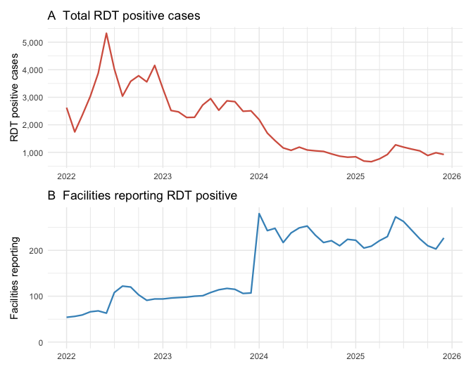

```r
monthly_both <- d_c[
  data %in% rdt_pos_cats & !is.na(original) &
    Month >= yearmonth("2022 Jan") & Month <= yearmonth("2025 Dec"),
  .(total_cases = sum(original, na.rm = TRUE),
    n_fac       = uniqueN(orgUnit)),
  by = Month
][order(Month)]

p_cases <- ggplot(monthly_both, aes(x = as.Date(Month), y = total_cases)) +
  geom_line(colour = "#d6604d", linewidth = 0.8) +
  scale_x_date(date_labels = "%Y", date_breaks = "1 year",
               date_minor_breaks = "3 months") +
  scale_y_continuous(labels = comma) +
  labs(x = NULL, y = "RDT positive cases",
       title = "A  Total RDT positive cases") +
  theme_minimal(base_size = 11) +
  theme(panel.grid.minor.x = element_line(colour = "grey90"))

p_facs <- ggplot(monthly_both, aes(x = as.Date(Month), y = n_fac)) +
  geom_line(colour = "#4393c3", linewidth = 0.8) +
  scale_x_date(date_labels = "%Y", date_breaks = "1 year",
               date_minor_breaks = "3 months") +
  scale_y_continuous(labels = comma, limits = c(0, NA)) +
  labs(x = NULL, y = "Facilities reporting",
       title = "B  Facilities reporting RDT positive") +
  theme_minimal(base_size = 11) +
  theme(panel.grid.minor.x = element_line(colour = "grey90"))

p_cases / p_facs
```

### 3.3 Indicator distortion from mismatched denominators

The problem is most acute when an indicator combines two elements — because the numerator and denominator may come from *different* sets of facilities. Test positivity (RDT positive ÷ suspects tested by RDT) is a standard malaria metric. If some facilities report tests but not positive results, or vice versa, the ratio is arithmetically meaningless.

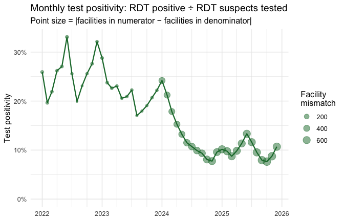

```r
monthly_pos  <- d_c[data %in% rdt_pos_cats & !is.na(original) &
                      Month >= yearmonth("2022 Jan") & Month <= yearmonth("2025 Dec"),
                    .(rdt_pos = sum(original, na.rm = TRUE),
                      n_pos   = uniqueN(orgUnit)), by = Month]
monthly_test <- d_c[data %in% tested_cats & !is.na(original) &
                      Month >= yearmonth("2022 Jan") & Month <= yearmonth("2025 Dec"),
                    .(rdt_test = sum(original, na.rm = TRUE),
                      n_test   = uniqueN(orgUnit)), by = Month]

monthly_tpr <- merge(monthly_pos, monthly_test, by = "Month")[
  , `:=`(tpr          = rdt_pos / rdt_test,
         fac_mismatch = abs(n_pos - n_test))
]

ggplot(monthly_tpr, aes(x = as.Date(Month))) +
  geom_line(aes(y = tpr), colour = "#1b7837", linewidth = 0.8) +
  geom_point(aes(y = tpr, size = fac_mismatch),
             colour = "#1b7837", alpha = 0.5) +
  scale_size_continuous(name = "Facility\nmismatch", range = c(1, 5)) +
  scale_y_continuous(labels = percent, limits = c(0, NA)) +
  scale_x_date(date_labels = "%Y", date_breaks = "1 year",
               date_minor_breaks = "3 months") +
  labs(x = NULL, y = "Test positivity",
       title = "Monthly test positivity: RDT positive ÷ RDT suspects tested",
       subtitle = "Point size = |facilities in numerator − facilities in denominator|") +
  theme_minimal(base_size = 12) +
  theme(panel.grid.minor.x = element_line(colour = "grey90"))
```

## 4 Champion facilities: identification and diagnostics

### 4.1 Definition

A **champion facility** is one that reports a specified set of data elements in every month (or nearly every month) of a given calendar year. A time series built from the same set of consistently reporting facilities has no reporting bias — any change reflects a true change in caseload, not a change in who submitted data.

Champions are identified per year by `mostFrequentReportingOUs()`. For the main analyses below we use:

- **Element:** MAL - RDT positive malaria cases (any age/sex category present, `any_selected` rule)
- **Date range:** January 2024 – December 2025 (two complete years where reporting is stable; see Section 4.3 for why earlier years are excluded)
- **Threshold:** 12/12 months required per year

```r
# --- Identify champions: RDT positive, 2024–2025, 12/12, any_selected ---
champ_ids <- mostFrequentReportingOUs(
  d_c,
  data_categories = rdt_pos_cats,
  startingMonth   = yearmonth("2024 Jan"),
  endingMonth     = yearmonth("2025 Dec"),
  missing_reports = 0L,
  reporting_rule  = "any_selected"
)

cat(sprintf("Champions (RDT positive, 12/12, 2024–2025): %d of %d facilities (%.0f%%)\n",
            length(champ_ids), n_total,
            100 * length(champ_ids) / n_total))
```

```
#> Champions (RDT positive, 12/12, 2024–2025): 37 of 1534 facilities (2%)
```

### 4.2 Diagnostic charts: how the app shows champion identification

MG2’s Reporting tab shows two charts at the top of the page. Reproduced here, they reveal how many facilities report consistently versus intermittently.

**Chart A** shows, for each year, the distribution of how many months each facility reported — essentially a census of reporting frequency. Black bars are all reporters; brown bars highlight the champion facilities (those at 12 months). The horizontal dashed line is the total number of facilities ever reporting. The gap between the top of the champion bar and the dashed line is the fraction of facilities that are *not* champions.

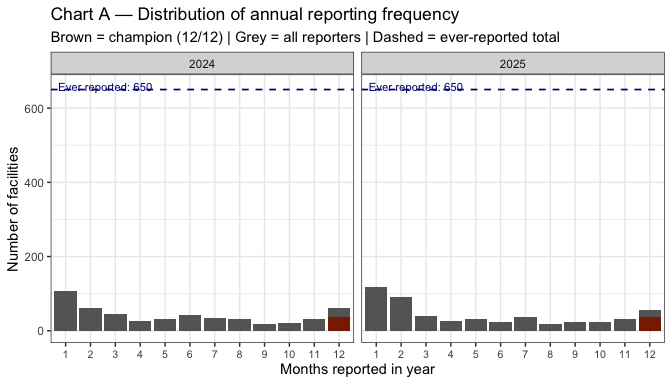

**Figure 4.** Distribution of months reported per year per facility, RDT positive malaria cases, 2024–2025 (Chart A from the Reporting tab). Black bars = all facilities; brown bars = champion facilities (12 months). The gap between the brown bar and the dashed line shows the proportion of facilities that are not champions in a given year.

```r
# Months reported per facility per year (2024–2025)
orep <- d_c[
  data %in% rdt_pos_cats & !is.na(original) &
    Month >= yearmonth("2024 Jan") & Month <= yearmonth("2025 Dec"),
  .(n_months = uniqueN(Month)),
  by = .(orgUnit, year = as.integer(format(Month, "%Y")))
]
orep[, n_months_f := factor(n_months, levels = 1:12)]

# Aggregate: all facilities
annual_all <- orep[, .(n = .N), by = .(year, n_months_f)]

# Aggregate: champions only
annual_champ <- orep[orgUnit %in% champ_ids,
                      .(n = .N), by = .(year, n_months_f)]

n_ever_win <- uniqueN(orep$orgUnit)  # facilities ever reporting in window

ggplot(annual_all, aes(x = n_months_f, y = n)) +
  geom_col(fill = "grey40") +
  geom_col(data = annual_champ, fill = "#8B2500", width = 0.9) +
  geom_hline(yintercept = n_ever_win, linetype = "dashed", colour = "navy",
             linewidth = 0.6) +
  annotate("text", x = 0.7, y = n_ever_win + 8,
           label = paste0("Ever reported: ", n_ever_win),
           hjust = 0, size = 3, colour = "navy") +
  facet_wrap(~year) +
  scale_x_discrete("Months reported in year", drop = FALSE) +
  scale_y_continuous("Number of facilities", labels = comma) +
  labs(title = "Chart A — Distribution of annual reporting frequency",
       subtitle = "Brown = champion (12/12) | Grey = all reporters | Dashed = ever-reported total") +
  theme_bw(base_size = 11) +
  theme(axis.text.x = element_text(size = 8))
```

**Chart B** shows the same data from a different angle: the number of facilities reporting in each calendar month, faceted by year. Black shows all reporters each month; brown shows only the champion subset. The gap between the brown and black lines is the non-champion reporters each month — facilities whose data that month contributes to reporting bias.

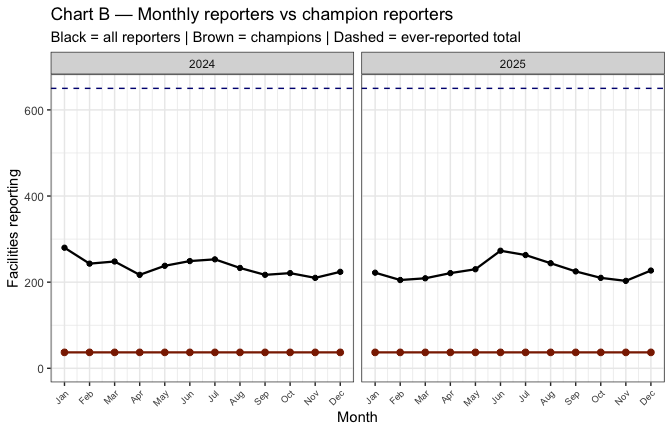

**Figure 5.** Number of facilities reporting RDT positive per calendar month, 2024–2025 (Chart B from the Reporting tab). Black = all facilities; brown/red = champion facilities. The dashed line is the ever-reported total. Champion facilities (brown) are a stable subset of the monthly reporters (black) — the black line’s variation from month to month is driven by non-champions entering and leaving.

```r
# Monthly reporters per month-of-year per year
omrep <- d_c[
  data %in% rdt_pos_cats & !is.na(original) &
    Month >= yearmonth("2024 Jan") & Month <= yearmonth("2025 Dec"),
  .(year     = as.integer(format(Month, "%Y")),
    month_n  = as.integer(format(Month, "%m"))),
  by = .(orgUnit, Month)
] |> unique()

monthly_all_yr <- omrep[,
  .(n_all = uniqueN(orgUnit)), by = .(year, month_n)
]
monthly_champ_yr <- omrep[orgUnit %in% champ_ids,
  .(n_champ = uniqueN(orgUnit)), by = .(year, month_n)
]
monthly_yr <- merge(monthly_all_yr, monthly_champ_yr,
                    by = c("year", "month_n"), all.x = TRUE)
monthly_yr[is.na(n_champ), n_champ := 0L]

ggplot(monthly_yr, aes(x = month_n)) +
  geom_line(aes(y = n_all),   colour = "black",   linewidth = 0.8) +
  geom_point(aes(y = n_all),  colour = "black",   size = 1.5) +
  geom_line(aes(y = n_champ), colour = "#8B2500", linewidth = 0.8) +
  geom_point(aes(y = n_champ), colour = "#8B2500", size = 2) +
  geom_hline(yintercept = n_ever_win, linetype = "dashed", colour = "navy",
             linewidth = 0.5) +
  facet_wrap(~year) +
  scale_x_continuous("Month", breaks = 1:12, labels = month.abb) +
  scale_y_continuous("Facilities reporting", labels = comma, limits = c(0, NA)) +
  labs(title = "Chart B — Monthly reporters vs champion reporters",
       subtitle = "Black = all reporters | Brown = champions | Dashed = ever-reported total") +
  theme_bw(base_size = 11) +
  theme(axis.text.x = element_text(angle = 45, hjust = 1, size = 7))
```

### 4.3 Why the date range of analysis matters

The date range used to define champions is one of the most consequential analytic choices, yet it is easy to overlook.

`mostFrequentReportingOUs()` requires a facility to report consistently in **every year** of the analysis window. A facility that began reporting in 2024 will not qualify for a 2022–2025 window even if it reports perfectly in 2024 and 2025 — because it has no data in 2022 or 2023.

The Lao PDR data illustrates this dramatically. RDT positive reporting expanded about three-fold in 2024 (Figure 1). Many facilities in the 2024–2025 reporting system simply did not exist in the 2022–2023 system. Extending the window back to 2022 eliminates nearly all champions.

```r
# Champion counts under different start years (RDT positive, 12/12, any_selected)
date_windows <- list(
  "2022–2025 (4 years)" = c("2022 Jan", "2025 Dec"),
  "2023–2025 (3 years)" = c("2023 Jan", "2025 Dec"),
  "2024–2025 (2 years)" = c("2024 Jan", "2025 Dec"),
  "2024 only (1 year)"  = c("2024 Jan", "2024 Dec"),
  "2025 only (1 year)"  = c("2025 Jan", "2025 Dec")
)

range_results <- lapply(names(date_windows), function(nm) {
  w   <- date_windows[[nm]]
  ids <- mostFrequentReportingOUs(
    d_c,
    data_categories = rdt_pos_cats,
    startingMonth   = yearmonth(w[1]),
    endingMonth     = yearmonth(w[2]),
    missing_reports = 0L,
    reporting_rule  = "any_selected"
  )
  data.frame(
    `Analysis window` = nm,
    `Champion facilities` = length(ids),
    `% of all facilities`  = scales::percent(length(ids) / n_total, 0.1),
    check.names = FALSE
  )
})

knitr::kable(
  do.call(rbind, range_results),
  caption = paste0(
    "Table 2. Champion facility counts (MAL - RDT positive, 12/12 threshold,",
    " any_selected rule) under different analysis windows.",
    " Total facilities ever reporting: ", comma(n_total), "."
  )
)
```

Table 2. Champion facility counts (MAL - RDT positive, 12/12 threshold, any_selected rule) under different analysis windows. Total facilities ever reporting: 1,534.

| Analysis window | Champion facilities | % of all facilities |
| --- | --- | --- |
| 2022–2025 (4 years) | 0 | 0.0% |
| 2023–2025 (3 years) | 0 | 0.0% |
| 2024–2025 (2 years) | 37 | 2.4% |
| 2024 only (1 year) | 61 | 4.0% |
| 2025 only (1 year) | 55 | 3.6% |

**Key message from Table 2:** The 2022–2025 window yields zero champions because the 2024–2025 reporting system and the 2022–2023 reporting system represent largely different facilities. Starting the window in 2024 — when the current reporting system became established — yields a meaningful champion set (37 facilities that reported every month in both 2024 and 2025).

For a two-year window, analysts should verify that the facilities that are active in year 2 are also active in year 1. A sharp year-over-year increase in reporting facilities, as seen here, is a signal that the two years are not comparable and the window should be shortened.

### 4.4 Champion trend vs. raw trend

The point of champions is to produce an unbiased time series. Figure 6 directly compares the monthly RDT positive total for all facilities vs. champion facilities only, over the 2024–2025 period. The champion series (brown) is smoother and reflects changes in incidence; the all-facility series (black) additionally absorbs fluctuations driven by which facilities happened to submit that month.

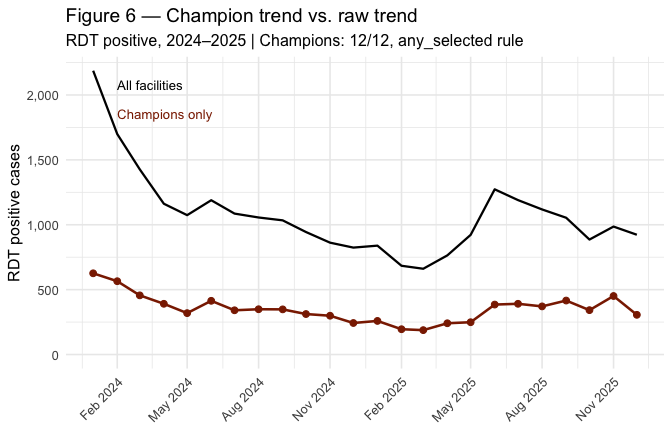

**Figure 6.** Monthly RDT positive malaria cases, 2024–2025: all reporting facilities (black) vs champion facilities only (brown, 12/12 threshold, any_selected rule). The champion series is smoother because it is not affected by month-to-month variation in which facilities happened to report. Differences between the two lines reflect the contribution of non-champion reporters.

```r
monthly_raw_champ <- d_c[
  data %in% rdt_pos_cats & !is.na(original) &
    Month >= yearmonth("2024 Jan") & Month <= yearmonth("2025 Dec"),
  .(total_all   = sum(original, na.rm = TRUE),
    total_champ = sum(original[orgUnit %in% champ_ids], na.rm = TRUE)),
  by = Month
][order(Month)]

ggplot(monthly_raw_champ, aes(x = as.Date(Month))) +
  geom_line(aes(y = total_all),   colour = "black",   linewidth = 0.8,
            linetype = "solid") +
  geom_line(aes(y = total_champ), colour = "#8B2500", linewidth = 0.9,
            linetype = "solid") +
  geom_point(aes(y = total_champ), colour = "#8B2500", size = 2) +
  scale_x_date(date_labels = "%b %Y", date_breaks = "3 months") +
  scale_y_continuous(labels = comma, limits = c(0, NA)) +
  annotate("text", x = as.Date(yearmonth("2024 Feb")),
           y = max(monthly_raw_champ$total_all) * 0.95,
           label = "All facilities", hjust = 0, colour = "black", size = 3.5) +
  annotate("text", x = as.Date(yearmonth("2024 Feb")),
           y = max(monthly_raw_champ$total_all) * 0.85,
           label = "Champions only", hjust = 0, colour = "#8B2500", size = 3.5) +
  labs(x = NULL, y = "RDT positive cases",
       title = "Figure 6 — Champion trend vs. raw trend",
       subtitle = "RDT positive, 2024–2025 | Champions: 12/12, any_selected rule") +
  theme_minimal(base_size = 12) +
  theme(axis.text.x = element_text(angle = 45, hjust = 1))
```

### 4.5 Effect of the reporting rule on champion count

The four reporting rules available in MG2’s Reporting tab change which facility- months count as “reporting.” Table 3 shows the impact on champion count for the same element set (RDT positive) and the same 2024–2025 window.

```r
rules <- c(
  "all_categories" = "All selected elements — every category present",
  "all_elements"   = "All selected elements — at least one category",
  "any_selected"   = "Any selected element present  ← default",
  "any_data"       = "Any data element present (incl. unchecked)"
)

rule_results <- lapply(names(rules), function(r) {
  ids <- mostFrequentReportingOUs(
    d_c,
    data_categories = rdt_pos_cats,
    startingMonth   = yearmonth("2024 Jan"),
    endingMonth     = yearmonth("2025 Dec"),
    missing_reports = 0L,
    reporting_rule  = r
  )
  data.frame(
    Rule        = rules[[r]],
    Champions   = length(ids),
    `% of all`  = scales::percent(length(ids) / n_total, 0.1),
    check.names = FALSE
  )
})

knitr::kable(
  do.call(rbind, rule_results),
  caption = paste0(
    "Table 3. Champion count by reporting rule, MAL - RDT positive malaria cases,",
    " 12/12 threshold, 2024–2025."
  )
)
```

Table 3. Champion count by reporting rule, MAL - RDT positive malaria cases, 12/12 threshold, 2024–2025.

| Rule | Champions | % of all |
| --- | --- | --- |
| All selected elements — every category present | 30 | 2.0% |
| All selected elements — at least one category | 37 | 2.4% |
| Any selected element present ← default | 37 | 2.4% |
| Any data element present (incl. unchecked) | 1135 | 74.0% |

For RDT positive (which has 6 age × sex categories per facility), `all_categories` requires all six to be present every month — the strictest test. `any_selected` (the default) only requires that at least one category has a non-missing value. The `any_data` rule counts any non-missing data in the entire dataset regardless of element, making it the most inclusive.

Use `all_categories` when computing age- or sex-specific rates where an incomplete breakdown produces an undefined result. Use `any_selected` for burden estimation where the element total is what matters.

## 5 Element selection and the double-counting risk

### 5.1 A structural ambiguity in the Lao PDR data

The Lao PDR DHIS2 system records confirmed malaria cases in overlapping fields:

- **MAL - Confirmed malaria cases** — an aggregate field (by age group), available from November 2024 only
- **MAL - RDT positive malaria cases** — RDT-specific (by age × sex), available from January 2022
- **MAL - Microscopy positive malaria cases** — microscopy-specific (by age × sex), available from January 2022

In this DHIS2 configuration the confirmed-cases field is meant to capture all confirmed cases (RDT positive + microscopy positive combined). If that is how facilities fill in the form, requiring all three as champion criteria asks for the same case to be recorded three times — and penalises facilities that correctly use only the aggregate field.

### 5.2 Empirical check: are the fields redundant?

The overlap period where all three elements coexist is November 2024 – May 2026 (19 months). The scatter plot below tests whether Confirmed ≈ RDT positive + Microscopy positive at the facility-month level.

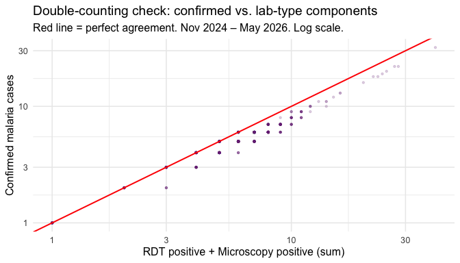

**Figure 7.** Relationship between the aggregate confirmed-cases field and the sum of RDT positive + microscopy positive, by facility-month (November 2024 – May 2026). Points on the red 45° line indicate the fields are recording identical cases. Log scale; facility-months where either source = 0 excluded.

```r
# Overlap period: Nov 2024 – May 2026
dc_start <- yearmonth("2024 Nov")
dc_end   <- yearmonth("2026 May")

dc_long <- rbind(
  d_c[data %in% conf_cats    & !is.na(original) & Month >= dc_start & Month <= dc_end,
      .(val = sum(original, na.rm = TRUE), type = "confirmed"), by = .(orgUnit, Month)],
  d_c[data %in% rdt_pos_cats & !is.na(original) & Month >= dc_start & Month <= dc_end,
      .(val = sum(original, na.rm = TRUE), type = "rdt_pos"),  by = .(orgUnit, Month)],
  d_c[data %in% micro_cats   & !is.na(original) & Month >= dc_start & Month <= dc_end,
      .(val = sum(original, na.rm = TRUE), type = "micro_pos"), by = .(orgUnit, Month)]
)
dc_wide <- dcast(dc_long, orgUnit + Month ~ type,
                 value.var = "val", fun.aggregate = sum, fill = NA_real_)
dc_wide[, lab_sum := rdt_pos + micro_pos]

ggplot(dc_wide[!is.na(confirmed) & !is.na(lab_sum) &
                 confirmed > 0 & lab_sum > 0],
       aes(x = lab_sum, y = confirmed)) +
  geom_point(alpha = 0.2, size = 0.8, colour = "#762a83") +
  geom_abline(slope = 1, intercept = 0, colour = "red", linewidth = 0.7) +
  scale_x_log10(labels = comma) +
  scale_y_log10(labels = comma) +
  labs(x = "RDT positive + Microscopy positive (sum)",
       y = "Confirmed malaria cases",
       title = "Double-counting check: confirmed vs. lab-type components",
       subtitle = "Red line = perfect agreement. Nov 2024 – May 2026. Log scale.") +
  theme_minimal(base_size = 12)
```

```r
dc_check <- dc_wide[!is.na(confirmed) & !is.na(lab_sum)]
cor_sp    <- cor(dc_check$confirmed, dc_check$lab_sum,
                 use = "complete.obs", method = "spearman")
agree_pct <- mean(abs(dc_check$confirmed - dc_check$lab_sum) <= 1,
                  na.rm = TRUE)

cat(sprintf("Spearman correlation (confirmed vs lab sum):             %.3f\n", cor_sp))
```

```
#> Spearman correlation (confirmed vs lab sum):             0.936
```

```r
cat(sprintf("Facility-months within ±1 case of agreement:            %.1f%%\n",
            100 * agree_pct))
```

```
#> Facility-months within ±1 case of agreement:            71.0%
```

### 5.3 Suspected ≠ Tested

- **MAL - Suspected malaria cases** counts patients presenting with fever (clinical tally, before testing)
- **MAL - Malaria suspects tested (RDT)** counts patients who actually received an RDT (laboratory tally)

These answer different questions. A champion criterion that requires *both* conflates the care-seeking and diagnostic pathways, and many high-performing facilities consistently report only one.

### 5.4 Recommended element set for Lao PDR

For estimating confirmed malaria burden:

| Analysis period | Recommended element(s) | Rationale |
| --- | --- | --- |
| Jan 2022 – present | RDT positive malaria cases | Longest consistently available series |
| Nov 2024 – present | Confirmed malaria cases | Aggregate field; check for redundancy with lab types first |
| For test positivity | RDT positive + Suspects tested (RDT) | Matched numerator / denominator |

For all analyses, use `any_selected` unless every age/sex breakdown is required.

## 6 Comparing champion sets across element sets and thresholds

```r
# Element sets
narrow_elems <- rdt_pos_cats
medium_elems <- c(rdt_pos_cats, tested_cats)
broad_elems  <- c(rdt_pos_cats, micro_cats, tested_cats)

# Labels for display
set_labels <- c(
  "Narrow (RDT positive only)",
  "Medium — recommended (RDT positive + suspects tested)",
  "Broad (RDT positive + microscopy positive + suspects tested)"
)

# Compute per year, then average
get_avg_champs <- function(elems, missing_allowed, rule, years = 2024:2025) {
  ns <- vapply(years, function(yr) {
    length(mostFrequentReportingOUs(
      d_c,
      data_categories = elems,
      startingMonth   = yearmonth(paste0(yr, " Jan")),
      endingMonth     = yearmonth(paste0(yr, " Dec")),
      missing_reports = missing_allowed,
      reporting_rule  = rule
    ))
  }, integer(1L))
  round(mean(ns))
}

grid <- expand.grid(
  set_idx   = 1:3,
  threshold = c(0L, 1L, 2L),
  stringsAsFactors = FALSE
)
elem_list <- list(narrow_elems, medium_elems, broad_elems)

grid$n_champ <- mapply(
  function(si, th) get_avg_champs(elem_list[[si]], th, "any_selected"),
  si = grid$set_idx, th = grid$threshold
)
grid$pct     <- scales::percent(grid$n_champ / n_total, 0.1)
grid$label   <- set_labels[grid$set_idx]
grid$thresh  <- paste0(12L - grid$threshold, "/12")

tbl6 <- grid[, c("label", "thresh", "n_champ", "pct")] |>
  setNames(c("Element set", "Months required",
             "Champions (avg 2024–2025)", "% of all facilities"))

knitr::kable(
  tbl6,
  caption = paste0(
    "Table 4. Champion facility counts by element set and monthly threshold,",
    " any_selected rule, average of 2024 and 2025.",
    " Total facilities ever reporting: ", comma(n_total), "."
  )
)
```

Table 4. Champion facility counts by element set and monthly threshold, any_selected rule, average of 2024 and 2025. Total facilities ever reporting: 1,534.

| Element set | Months required | Champions (avg 2024–2025) | % of all facilities |
| --- | --- | --- | --- |
| Narrow (RDT positive only) | 12/12 | 58 | 3.8% |
| Medium — recommended (RDT positive + suspects tested) | 12/12 | 466 | 30.4% |
| Broad (RDT positive + microscopy positive + suspects tested) | 12/12 | 472 | 30.8% |
| Narrow (RDT positive only) | 11/12 | 90 | 5.9% |
| Medium — recommended (RDT positive + suspects tested) | 11/12 | 572 | 37.3% |
| Broad (RDT positive + microscopy positive + suspects tested) | 11/12 | 581 | 37.9% |
| Narrow (RDT positive only) | 10/12 | 112 | 7.3% |
| Medium — recommended (RDT positive + suspects tested) | 10/12 | 640 | 41.7% |
| Broad (RDT positive + microscopy positive + suspects tested) | 10/12 | 649 | 42.3% |

## 7 Representativeness of the champion set

A champion set is useful for extrapolation only when its facilities resemble the full set in terms of caseload and geography. MG2’s Reporting tab provides two diagnostics.

```r
# Champions for representativeness: medium set (RDT positive + suspects tested)
# 11/12 threshold, 2024–2025
champ_med_ids <- mostFrequentReportingOUs(
  d_c,
  data_categories = medium_elems,
  startingMonth   = yearmonth("2024 Jan"),
  endingMonth     = yearmonth("2025 Dec"),
  missing_reports = 1L,
  reporting_rule  = "any_selected"
)

cat(sprintf("Medium element set, 11/12, 2024–2025: %d champions (%.0f%%)\n",
            length(champ_med_ids),
            100 * length(champ_med_ids) / n_total))
```

```
#> Medium element set, 11/12, 2024–2025: 417 champions (27%)
```

```r
# Median monthly RDT positive per facility, 2024–2025
med_vals <- d_c[
  data %in% rdt_pos_cats & !is.na(original) &
    Month >= yearmonth("2024 Jan") & Month <= yearmonth("2025 Dec"),
  .(median_cases = median(original, na.rm = TRUE)),
  by = orgUnit
]
med_vals[, Champion := fifelse(orgUnit %in% champ_med_ids,
                               "Champion", "Non-Champion")]
med_vals <- merge(med_vals, fac_meta, by = "orgUnit", all.x = TRUE)
```

**Box plot (Figure 8):** If champion and non-champion distributions overlap substantially, the champion set is reasonably representative by volume.

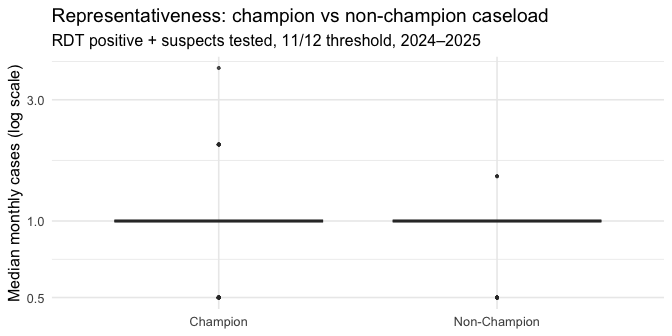

**Figure 8.** Distribution of median monthly RDT positive cases per facility (2024–2025): champion vs non-champion (medium element set, 11/12 threshold). Log scale; facilities with median = 0 excluded. Substantial overlap indicates that champion facilities are not systematically higher- or lower-volume than non-champions.

```r
ggplot(med_vals[median_cases > 0],
       aes(x = Champion, y = median_cases, fill = Champion)) +
  geom_boxplot(outlier.size = 0.7, alpha = 0.8) +
  scale_y_log10(labels = comma) +
  scale_fill_manual(values = c("Champion" = "#4393c3",
                               "Non-Champion" = "#d6604d")) +
  labs(x = NULL, y = "Median monthly cases (log scale)",
       title = "Representativeness: champion vs non-champion caseload",
       subtitle = "RDT positive + suspects tested, 11/12 threshold, 2024–2025") +
  theme_minimal(base_size = 12) +
  theme(legend.position = "none")
```

**Province chart (Figure 9):** Shows whether champions are geographically representative. Systematic gaps in specific provinces signal that the champion- based extrapolation may not transfer to those areas without adjustment.

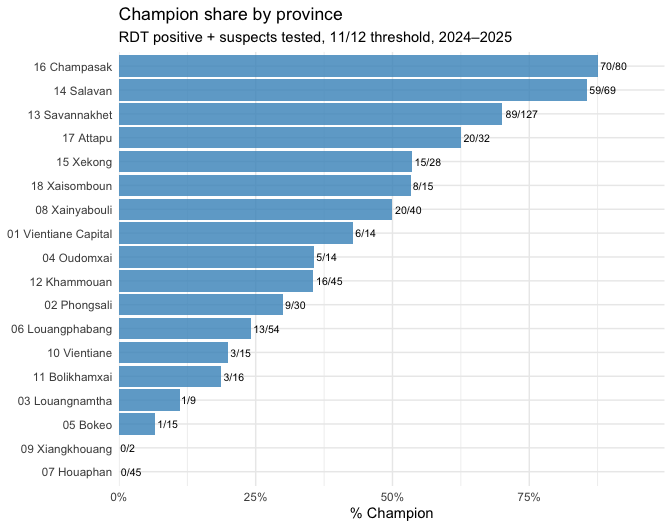

**Figure 9.** Champion share by province (medium element set, 11/12 threshold, 2024–2025). Sorted from lowest to highest champion share. The facility count (n champions / n total) is shown at the end of each bar. Provinces with very low champion shares may require special attention in the extrapolation step.

```r
prov_sum <- med_vals[
  , .(total = .N,
      n_champ = sum(Champion == "Champion", na.rm = TRUE)),
  by = Province
][, pct_champ := n_champ / total
][order(pct_champ)]
prov_sum[, Province := factor(Province, levels = Province)]

ggplot(prov_sum, aes(x = pct_champ, y = Province)) +
  geom_col(fill = "#4393c3", alpha = 0.8) +
  geom_text(aes(label = paste0(n_champ, "/", total)),
            hjust = -0.1, size = 2.8) +
  scale_x_continuous(labels = percent,
                     expand = expansion(mult = c(0, 0.14))) +
  labs(x = "% Champion", y = NULL,
       title = "Champion share by province",
       subtitle = "RDT positive + suspects tested, 11/12 threshold, 2024–2025") +
  theme_minimal(base_size = 11)
```

## 8 Summary and reporting standards

### What to include in a methods section

1. **Which elements defined the champion criterion** — e.g., “RDT positive malaria cases (any age/sex category present) or suspects tested by RDT.”
2. **The reporting rule** — e.g., “`any_selected`: a facility was credited as reporting in a given month if at least one selected element had a non-missing value.”
3. **The analysis window and rationale** — e.g., “January 2024 – December 2025, corresponding to the period of stable reporting system participation. An earlier start date (2022 or 2023) was explored but yielded zero champions due to the 2024 expansion of the reporting system.”
4. **The monthly threshold** — e.g., “12 of 12 months per year required (zero missing months allowed).”
5. **Champion counts and share** — e.g., “Of N facilities ever reporting, M were champions in 2024 and M’ in 2025 (X% and X’% of all facilities).”
6. **A representativeness statement** — noting whether champion and non-champion caseloads are similar (Figure 8) and whether champions are geographically distributed across provinces (Figure 9).

### Forward note: imputation

The champion-facility approach produces an unbiased total *for the champion set*. To estimate totals for *all* facilities, MG2 extrapolates by scaling champion- facility rates to the full expected-facility denominator within each geographic unit. A complementary approach — imputing missing months for non-champion facilities using time-series models — is covered in the evaluation vignette.